# CryptoCurrency Analysis

### Cryptocurrency:

A cryptocurrency (or crypto currency or crypto for short) is a digital asset designed to work as a medium of exchange wherein individual coin ownership records are stored in a ledger existing in a form of computerized database using strong cryptography to secure transaction records, to control the creation of additional coins, and to verify the transfer of coin ownership.

The cryptocurrency market has been volatile from the very beginning, but the last couple of years have been a particularly wild ride for millions of investors around the world. Many have made millions on the big upswings, and yet many have lost large and small investments in the bursting bubbles and sudden market downturns.

### Gathering Data:

Once the requirements are clearly understood, the data will then be loaded into python jupyter notebook using pandas library. Once data has been uploaded and viewable, we will check its data type to understand what kind of data we are dealing with. From the given set of data, we will extract the following columns:

1) Currency (Object) 2) Date (Datetime) 3) High (Float) 4) Volume (Int)

### Data Wrangling , Validation and Creating Pivot Tables:

We will convert the data types to continuous variables so that we can create visualizations. We will also then check for missing data and deal with them accordingly. Once the data has been cleansed, we will now move towards visualization. In order to create the required visuals we will first create two more dataframes in order to meet the required visuals. We will create a dataframe consisting of Currency,Date and High for the first visual, and for the Second Data frame we will select Currency,Date and Volume for the second visual. These dataframes will be converted into pivot tables setting Date as index, Currency as column and High as value in first dataframe where as in the second dataframe, we will first filter the Date to show values from 2016-2019 and top 3 Currencies I.e Bitcoin, Ethereum and Tether and then convert the dataframe into a pivot table where Date is index, Currency is Column and Volume are values.

### Visualization:

After creating the pivot tables we will create line plot and box plot using matplotlib for the first requirement. A line graph is commonly used to display change over time as a series of data points connected by straight line segments on two axes. It is simple and clearly shows the change in value over the course of time. Box plots are a type of graph that can help visually organize data. Once the box plot is graphed, you can display and compare distributions of data. These visuals are useful particularly in financial analysis and can cater both age groups. The colors used will be sober and visualy appealing to both age groups.

For the second requirement we will again create a line plot and a bar plot using matplotlib. The reason for line graphs is same as it was in the first requirement whereas A bar chart or bar graph is a chart or graph that presents categorical data with rectangular bars with heights or lengths proportional to the values that they represent. It is another simple representation and shows the change in volume over a course of time.

Importing Required Libraries

```python
import pandas as pd
import numpy as np
import matplotlib.pylab as plt
import seaborn as sns
%matplotlib inline
```

Reading the CSV File

```python
df = pd.read_csv("D:\\Documents\\Assignment\\consolidated_coin_data.csv", delimiter=",")
print ('Data read into a pandas dataframe!')
```

```
Data read into a pandas dataframe!
```

```python
df.head() #Calling first 5 rows
```

|  | Currency | Date | Open | High | Low | Close | Volume | Market Cap |
| --- | --- | --- | --- | --- | --- | --- | --- | --- |
| 0 | tezos | 4-Dec-19 | 1.29 | 1.32 | 1.25 | 1.25 | 46048752 | 824588509 |
| 1 | tezos | 3-Dec-19 | 1.24 | 1.32 | 1.21 | 1.29 | 41462224 | 853213342 |
| 2 | tezos | 2-Dec-19 | 1.25 | 1.26 | 1.20 | 1.24 | 27574097 | 817872179 |
| 3 | tezos | 1-Dec-19 | 1.33 | 1.34 | 1.25 | 1.25 | 24127567 | 828296390 |
| 4 | tezos | 30-Nov-19 | 1.31 | 1.37 | 1.31 | 1.33 | 28706667 | 879181680 |

```python
df.dtypes #Checking Datatypes
```

```
Currency       object
Date           object
Open          float64
High          float64
Low           float64
Close         float64
Volume          int64
Market Cap      int64
dtype: object
```

```python
df['Date'] = pd.to_datetime(df['Date'])
df[['Date']] = pd.DatetimeIndex(df['Date']).year #Converting Datatypes to years for better representation
```

```python
df.dtypes #Checking updated column
```

```
Currency       object
Date            int64
Open          float64
High          float64
Low           float64
Close         float64
Volume          int64
Market Cap      int64
dtype: object
```

```python
df.describe() #Understanding the data
```

|  | Date | Open | High | Low | Close | Volume | Market Cap |
| --- | --- | --- | --- | --- | --- | --- | --- |
| count | 28944.000000 | 28944.000000 | 28944.000000 | 28944.000000 | 28944.000000 | 2.894400e+04 | 2.894400e+04 |
| mean | 2016.111940 | 300.719748 | 309.832808 | 290.858372 | 300.947362 | 8.133058e+08 | 7.194826e+09 |
| std | 1.920268 | 1373.884718 | 1416.598612 | 1325.072673 | 1374.461259 | 3.059516e+09 | 2.469322e+10 |
| min | 2013.000000 | 0.000000 | 0.000000 | 0.000000 | 0.000000 | 0.000000e+00 | 0.000000e+00 |
| 25% | 2014.000000 | 0.210000 | 0.210000 | 0.200000 | 0.210000 | 2.418700e+05 | 6.345143e+07 |
| 50% | 2016.000000 | 2.995000 | 3.090000 | 2.880000 | 2.980000 | 5.212684e+06 | 3.453673e+08 |
| 75% | 2018.000000 | 24.430000 | 25.530000 | 23.270000 | 24.430000 | 1.554764e+08 | 3.422403e+09 |
| max | 2019.000000 | 19475.800000 | 20089.000000 | 18974.100000 | 19497.400000 | 5.350913e+10 | 3.265025e+11 |

```python
df.info(verbose=False) #Information about the dataframe
```

```
<class 'pandas.core.frame.DataFrame'>
RangeIndex: 28944 entries, 0 to 28943
Columns: 8 entries, Currency to Market Cap
dtypes: float64(4), int64(3), object(1)
memory usage: 1.8+ MB
```

Checking for Missing Data

```python
missing_data = df.isnull()
missing_data.head(5)
```

|  | Currency | Date | Open | High | Low | Close | Volume | Market Cap |
| --- | --- | --- | --- | --- | --- | --- | --- | --- |
| 0 | False | False | False | False | False | False | False | False |
| 1 | False | False | False | False | False | False | False | False |
| 2 | False | False | False | False | False | False | False | False |
| 3 | False | False | False | False | False | False | False | False |
| 4 | False | False | False | False | False | False | False | False |

```python
df.isnull().sum()
```

```
Currency      0
Date          0
Open          0
High          0
Low           0
Close         0
Volume        0
Market Cap    0
dtype: int64
```

```python
df.corr() #Checking Correlation between columns
```

|  | Date | Open | High | Low | Close | Volume | Market Cap |
| --- | --- | --- | --- | --- | --- | --- | --- |
| Date | 1.000000 | 0.184136 | 0.183393 | 0.185257 | 0.184023 | 0.345563 | 0.268524 |
| Open | 0.184136 | 1.000000 | 0.999268 | 0.998868 | 0.998551 | 0.560011 | 0.953660 |
| High | 0.183393 | 0.999268 | 1.000000 | 0.998588 | 0.999403 | 0.561062 | 0.954377 |
| Low | 0.185257 | 0.998868 | 0.998588 | 1.000000 | 0.999205 | 0.559677 | 0.954393 |
| Close | 0.184023 | 0.998551 | 0.999403 | 0.999205 | 1.000000 | 0.560457 | 0.955012 |
| Volume | 0.345563 | 0.560011 | 0.561062 | 0.559677 | 0.560457 | 1.000000 | 0.591818 |
| Market Cap | 0.268524 | 0.953660 | 0.954377 | 0.954393 | 0.955012 | 0.591818 | 1.000000 |

To view the dimensions of the dataframe, we use the .shape parameter.

```python
df.shape # size of dataframe (rows, columns)
```

```
(28944, 8)
```

```python
df1 = df[['Currency','Date','High']] #creating new dataframe
```

```python
df1 = df1.groupby(['Currency','Date'],as_index=False).max() #Using groupby function to create required pivot table
df1
```

|  | Currency | Date | High |
| --- | --- | --- | --- |
| 0 | binance-coin | 2013 | 53.15 |
| 1 | binance-coin | 2014 | 32.06 |
| 2 | binance-coin | 2015 | 8.73 |
| 3 | binance-coin | 2016 | 5.95 |
| 4 | binance-coin | 2017 | 53.55 |
| ... | ... | ... | ... |
| 79 | xrp | 2015 | 0.02 |
| 80 | xrp | 2016 | 0.01 |
| 81 | xrp | 2017 | 2.85 |
| 82 | xrp | 2018 | 3.84 |
| 83 | xrp | 2019 | 0.51 |

84 rows × 3 columns

```python
grouped_pivot = df1.pivot(index='Date',columns='Currency',values='High') #Creating Pivot Table
grouped_pivot
```

| Currency Date | binance-coin | bitcoin | bitcoin-cash | bitcoin-sv | cardano | eos | ethereum | litecoin | stellar | tether | tezos | xrp |
| --- | --- | --- | --- | --- | --- | --- | --- | --- | --- | --- | --- | --- |
| 2013 | 53.15 | 1156.14 | 147.49 | 53.15 | 53.15 | 53.15 | 1156.14 | 53.15 | 53.15 | 147.49 | 53.15 | 147.49 |
| 2014 | 32.06 | 1017.12 | 0.03 | 32.06 | 32.06 | 32.06 | 1017.12 | 32.06 | 32.06 | 0.03 | 32.06 | 0.03 |
| 2015 | 8.73 | 495.56 | 1.22 | 8.73 | 0.01 | 8.73 | 320.43 | 8.73 | 0.01 | 1.22 | 0.01 | 0.02 |
| 2016 | 5.95 | 979.40 | 1.01 | 5.95 | 0.00 | 5.95 | 21.52 | 5.95 | 0.00 | 1.01 | 0.00 | 0.01 |
| 2017 | 53.55 | 20089.00 | 4355.62 | 53.55 | 0.78 | 53.55 | 881.94 | 375.29 | 0.39 | 1.21 | 12.19 | 2.85 |
| 2018 | 24.91 | 17712.40 | 3071.16 | 243.79 | 1.33 | 22.89 | 1432.88 | 323.11 | 0.94 | 1.07 | 7.55 | 3.84 |
| 2019 | 39.57 | 13796.49 | 522.09 | 255.88 | 0.11 | 8.59 | 361.40 | 146.43 | 0.16 | 1.06 | 1.83 | 0.51 |

```python
plt.style.use(['bmh']) # bmh Styling used for Visulization
```

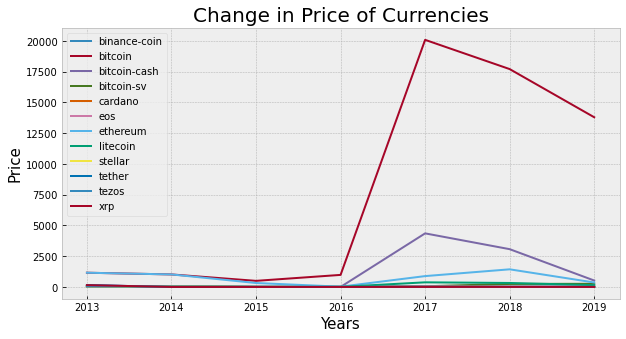

```python
grouped_pivot.plot(kind='line',figsize=(10,5))

plt.title('Change in Price of Currencies',fontsize = 20)
plt.ylabel('Price',fontsize = 15)
plt.xlabel('Years',fontsize = 15)
plt.legend(fontsize = 10)
plt.show()
```

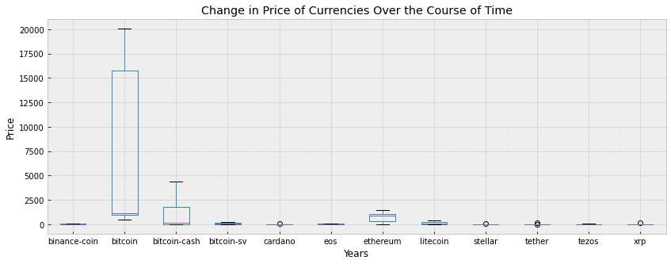

```python
grouped_pivot.plot(kind='box' ,figsize=(14, 5))

plt.title('Change in Price of Currencies Over the Course of Time')
plt.ylabel('Price')
plt.xlabel('Years')
plt.yticks(np.arange(0, 21000, 2500))
plt.show() # need this line to show the updates made to the figure
```

```python
df2 = df[['Currency','Date','Volume']]
df2 = df2.groupby(['Currency','Date'],as_index=False).max()
```

```python
df3 = df2[df2['Date'] > 2015]
df3.head()
```

|  | Currency | Date | Volume |
| --- | --- | --- | --- |
| 3 | binance-coin | 2016 | 19773600 |
| 4 | binance-coin | 2017 | 1730780032 |
| 5 | binance-coin | 2018 | 637020992 |
| 6 | binance-coin | 2019 | 742382920 |
| 10 | bitcoin | 2016 | 363320992 |

```python
df3_pivot = df3.pivot(index='Date',columns='Currency',values = 'Volume')
df3_pivot
```

| Currency Date | binance-coin | bitcoin | bitcoin-cash | bitcoin-sv | cardano | eos | ethereum | litecoin | stellar | tether | tezos | xrp |
| --- | --- | --- | --- | --- | --- | --- | --- | --- | --- | --- | --- | --- |
| 2016 | 19773600 | 363320992 | 7399410 | 19773600 | 2369690 | 19773600 | 199408000 | 19773600 | 2369690 | 7399410 | 2369690 | 15967600 |
| 2017 | 1730780032 | 22197999616 | 11889600512 | 1730780032 | 645155968 | 1730780032 | 5179829760 | 6961679872 | 537916032 | 4687949824 | 280844992 | 8108389888 |
| 2018 | 637020992 | 23840899072 | 5377260032 | 637020992 | 1713769984 | 4870720000 | 9214950400 | 3481550080 | 1513270016 | 6967777735 | 15960800 | 9110439936 |
| 2019 | 742382920 | 45105733173 | 4522945333 | 1701098408 | 340512939 | 5394932035 | 18661465873 | 6442000276 | 837742777 | 53509128965 | 123832790 | 9415068271 |

```python
df4 = df3[(df3['Currency'] == 'bitcoin') | (df3['Currency'] == 'ethereum') | (df3['Currency'] == 'tether')]
df4_pivot = df4.pivot(index='Date',columns='Currency',values = 'Volume')
df4_pivot
```

| Currency Date | bitcoin | ethereum | tether |
| --- | --- | --- | --- |
| 2016 | 363320992 | 199408000 | 7399410 |
| 2017 | 22197999616 | 5179829760 | 4687949824 |
| 2018 | 23840899072 | 9214950400 | 6967777735 |
| 2019 | 45105733173 | 18661465873 | 53509128965 |

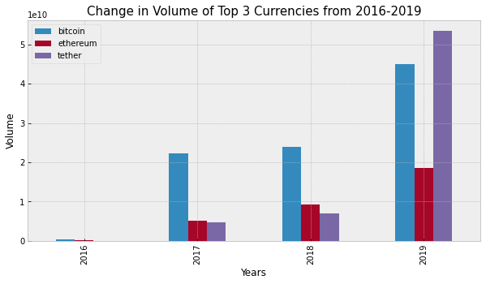

```python
df4_pivot.plot(kind='bar',figsize=(10, 5))
plt.title('Change in Volume of Top 3 Currencies from 2016-2019', fontsize = 15)
plt.ylabel('Volume')
plt.xlabel('Years')
plt.legend(fontsize = 10)
plt.show()
```

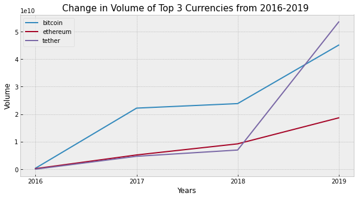

```python
df4_pivot.plot(kind='line',figsize=(10, 5)) #Line Chart for
plt.title('Change in Volume of Top 3 Currencies from 2016-2019 ', fontsize = 15)
plt.ylabel('Volume')
plt.xlabel('Years')
plt.xticks(np.arange(2016, 2020, 1))
plt.legend(fontsize = 10)
plt.show()
```